# Machine Learning

Conceitos e Exemplos

Wlademir Prates

# O que é Machine Learning?

> “Trata de um braço da Inteligência artificial que consiste em programar computadores de tal forma que eles possam **aprender a partir de dados**.”

## Como *machine learning* ajuda os negócios em geral?

ML é fundamental para extrair *insights* de grandes massas de dados e / ou de dados dispersos em várias fontes.

- Grandes massas de dados (*big data*) $\rightarrow$ Análises são **humanamente inviáveis**, e ferramentas de planilhas eletrônicas e softwares convencionais não suportam.
- **Dados dispersos** $\rightarrow$ Mesmo sem *big data*, o conhecimento é muito disperso e guardado em várias fontes de dados em diferentes áreas.

> Com isso, Machine Learning tem **saído do campo científico** e entrado cada vez mais no mundo dos negócios e no nosso dia a dia. Exemplos:
- Recomendações em plataformas de streaming.
- Recomendações de rotas em apps de trânsito.
- Modelos de linguagem, como ChatGPT.

# Objetivo principal em Data Science

> Em um projeto de *Data Science* em uma empresa, o que realmente importa é responder a **pergunta de negócio**, resolvendo o problema e apontando caminhos a serem seguidos pela organização.

# Tipos de análise estatística de dados

Com base puramente estatística:

- **Análise Descritiva** $\rightarrow$ Olhando para o passado.
  - Univariada (qualidade de dados, distribuição, dados faltantes, máximo, mínimo).
  - Bivariada (correlações, sumarizações, tabelas dinâmicas).

Com base em *Machine Learning*:

- **Análise Preditiva**
- **Análise Prescritiva**

**Análise Preditiva**

- Olhando para futuro.
- **Predições**: definem um resultado dadas as qualificações de uma situação.
- **Previsões** (séries temporais): utilizam-se também de informações do próprio passado para prever o futuro (sazonalidade, tendências, eventos).

**Análise Prescritiva**

- Dar conselhos em possíveis saídas.
- Recomendações de ações.
- Quantificação ordenada com base em probabilidade.
- Não são apenas algoritmos, mas uma mescla com **regras de negócios** e outras técnicas de mineração de dados.

# Categorias de modelos

> Para a parte de ML, podemos dividir os métodos em duas categorias:
1. Aprendizado Supervisionado
2. Aprendizado Não Supervisionado

**Não supervisionado**

- Não há um *target*.
- Explorar dados desconhecidos.
- Difícil de avaliar.

**Supervisionado**

- Há um *target* definido.
- É possível medir os *outputs*.
- Fácil de avaliar.

> Para os modelos supervisionados, temos os tipos de Regressão e de Classificação

## Regressão e classificação

São subcategorias do **aprendizado de máquina supervisionado**

- **Classificação**: predição em variáveis **categóricas** (binárias ou com *labels*).
- **Regressão**: predição em variáveis **numéricas**.

Um mesmo modelo pode servir tanto para regressão quanto classificação.

Veja exemplos de perguntas que definem se um modelo será de regressão ou classificação $\rightarrow$

| **Classificação** | **Regressão** |
| --- | --- |
| Chove ou não chove? | Quantos milímetros irá chover? |
| Faz hora extra ou não? | Quantas horas extras ele faz? |
| Qual faixa de etária? | Qual a idade? |
| Qual faixa de renda? | Qual a renda? |

# ML serve para tudo?

Para isso, **nem sempre *machine learning* será a saída mais adequada**. Veja exemplos de problemas e as técnicas mais adequadas.

## Problemas de negócios e técnicas para resolvê-los #1

- *Quem são os clientes mais lucrativos*?
  - **Solução**: consulta na base; painel de BI; filtros em **planilhas**.
- *Existe diferença entre o cliente lucrativo e o mediano*?
  - **Solução**: ser mais lucrativo pode ser acaso, por isso, indica-se métodos de **testes de hipóteses**.

## Problemas de negócios e técnicas para resolvê-los #2

- *Quais são as características dos clientes mais lucrativos*?
  - **Solução**: o mais adequado são técnicas de agrupamento, dentro de aprendizagem **não supervisionada**, como *clustering*.
- *Quais dos novos clientes se tornarão os mais lucrativos*?
  - **Solução**: modelos **preditivos** são os mais adequados, dentro de **aprendizagem supervisionada**.

## Problemas de negócios e técnicas para resolvê-los #3

- *Quais ações posso tomar para que um cliente venha a se enquadrar nos mais lucrativos*?
  - **Solução**: modelos **prescritivos**, que misturam predições, técnicas de mineração e aprendizagem automática. É o ponto mais avançado em *Data Science*.

Modelos prescritivos fornecem ações necessárias que têm maior probabilidade de resolver o problema de negócio em questão.

# Exemplos de aplicações de *machine learning* em negócios

1. **Manutenção**: recomendação de ações a serem tomadas, dado um determinado conjunto de erros.
2. **Logística**: probabilidade de ocorrência de falha em uma entrega.
3. *Churn*: encontrar perfis de clientes que provavelmente iriam gerar *churn* e adaptar as estratégias de vendas.
4. *Turnover*: identificar colaboradores com alta probabilidade de pedirem para sair e tomar ações.
5. **Sucessão** (RH): recomendar colaboradores com maior *fit* para assumir cargos de alta gestão.

## *Workflow* de *machine learning*

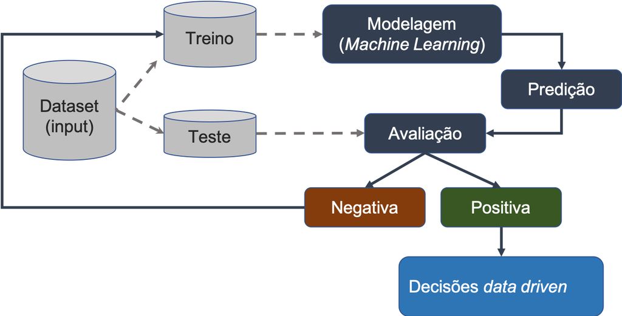